# Newton_Markdown_Demo

This is a small project to practice using GitHub.

I’d like to use the project to demonstrate a cool trick for displaying data in R Markdown. But, I want to make sure that group members find the skill useful.

**Here are three options for a cool trick we can explore.**

1. How to conditionally format tables in a markdown report - e.g., like this:

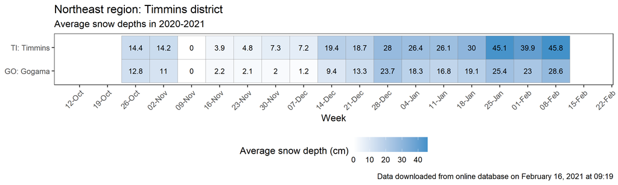

Northeast_Timmins

2. How to make your data tables, graphs, maps etc interactive in a html markdown report using `crosstalk`, which is like a “Shiny-light” to create simple widgets
3. How to save and use LIO’s topographic map backgrounds as a basemap for ggplot maps in R.

# You chose number 3!

### Your assignment is to choose one of the following tasks below and update the Rmd file here with your changes. Make sure you work on the assignment locally in RStudio. Pull the files from github to your local computer and when you’re done, push your changes to github and make a pull request so I can practice accepting your changes!

- Add a section to my “Using_LIO_maps.Rmd” where you bring in your own TIF and plot some points on it. Make sure you push the TIF to this repository so other people have access to it.
- Edit my map code to make the map “prettier”, or the way you would want it to look.
- Add a polygon to the first map that shows an area of interest in Peterborough.
- Add a section that uses the raster as the background of a leaflet style map.
- If you know how to get a raster from ArcGIS online, fix the last paragraph of code at the bottom!